# Prediction Assignment Writeup

Danielle

December 23, 2016

## Overview

One thing that people regularly do is quantify how much of a particular activity they do, but they rarely quantify how well they do it. In this project, our goal will be to use data from accelerometers on the belt, forearm, arm, and dumbell of 6 participants. The data for this project come from this source: http://groupware.les.inf.puc-rio.br/har.

## R Libraries

```r
library(RCurl)
library(caret)
library(randomForest)
```

```r
library(ggplot2)
library(gbm)
library(corrplot)
library(plyr)
library(MASS)
```

## Data Loading

Load data from url

```r
trainFile <- getURL('https://d396qusza40orc.cloudfront.net/predmachlearn/pml-training.csv', ssl.verifyhost=FALSE, ssl.verifypeer=FALSE)
testFile <- getURL('https://d396qusza40orc.cloudfront.net/predmachlearn/pml-testing.csv', ssl.verifyhost=FALSE, ssl.verifypeer=FALSE)

# ensure the results are repeatable
set.seed(7)
trainSet <- read.csv(textConnection(trainFile), header=T, na.strings=c("NA", "#DIV/0!"))
testSet <- read.csv(textConnection(testFile), header=T, na.strings=c("NA", "#DIV/0!"))
```

## Data Preprocessing

First split the train dataset to training and testing based on 70% : 30% ratio

```r
inTrain <- createDataPartition(trainSet$classe,p=0.70, list=FALSE)
training <- trainSet[inTrain,]
testing <- trainSet[-inTrain,]

#move "classe" column to the first column

training<-training[,c(which(colnames(training)=="classe"),which(colnames(training)!="classe"))]
testing<-testing[,c(which(colnames(testing)=="classe"),which(colnames(testing)!="classe"))]
dim(training)
```

```
## [1] 13737   160
```

And then remove columns with Near Zero variance

```r
training <- training[,-nearZeroVar(training[,-1])]
testing <- testing[,-nearZeroVar(testing[,-1])]
dim(training)
```

```
## [1] 13737   129
```

Some columns have lots of NAs. There columns need to be removed as well.

```r
#remove columns that have 10% NAs
pct_na <- unlist(lapply(training, function(x) mean(is.na(x))))
training <- training[,names(which(pct_na <= .9))]
testing <- testing[,names(which(pct_na <= .9))]
dim(training)
```

```
## [1] 13737    59
```

The columns “x”, “user_name”, “raw_timestamp_part_1”,“raw_timestamp_part_2”, “new_window”, “num_window” are user information and can be removed

```r
training <- training[,-c(2:7)]
testing <- testing[,-c(2:7)]
dim(training)
```

```
## [1] 13737    53
```

## Covariate Creation/Feature Extraction

Some attributes are highly correlated. The color intensity and the size of the circle in the following chart are proportional to the correlation coefficients.

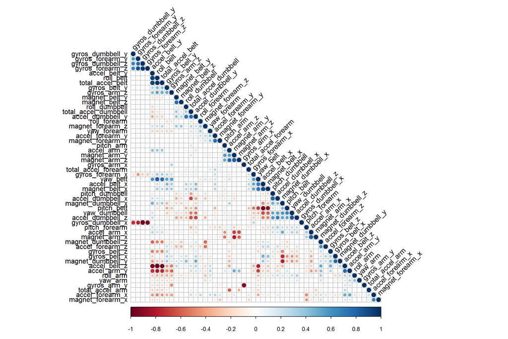

```r
#corrplot(cor(training[,-1]), order = "FPC", method = "color", type = "lower",
#         tl.cex = 0.8, tl.col = rgb(0, 0, 0))
corrplot(cor(training[,-1]), type = "lower", order = "hclust", tl.col = "black", tl.srt = 45)
```

We will find the attributes that are highly correlated (ideally >0.75) and remove them from the dataset.

```r
training.cor <- cor(training[,-1])
highlyCor <- findCorrelation(training.cor, cutoff = .75, verbose=TRUE,names=FALSE)
```

```
## Compare row 10  and column  1 with corr  0.992
##   Means:  0.271 vs 0.168 so flagging column 10
## Compare row 1  and column  9 with corr  0.927
##   Means:  0.251 vs 0.164 so flagging column 1
## Compare row 9  and column  4 with corr  0.929
##   Means:  0.235 vs 0.161 so flagging column 9
## Compare row 4  and column  22 with corr  0.756
##   Means:  0.212 vs 0.158 so flagging column 4
## Compare row 36  and column  29 with corr  0.849
##   Means:  0.254 vs 0.155 so flagging column 36
## Compare row 8  and column  2 with corr  0.966
##   Means:  0.239 vs 0.151 so flagging column 8
## Compare row 2  and column  11 with corr  0.88
##   Means:  0.221 vs 0.148 so flagging column 2
## Compare row 37  and column  38 with corr  0.773
##   Means:  0.191 vs 0.145 so flagging column 37
## Compare row 35  and column  30 with corr  0.775
##   Means:  0.192 vs 0.142 so flagging column 35
## Compare row 38  and column  5 with corr  0.787
##   Means:  0.171 vs 0.141 so flagging column 38
## Compare row 34  and column  28 with corr  0.808
##   Means:  0.18 vs 0.14 so flagging column 34
## Compare row 21  and column  24 with corr  0.814
##   Means:  0.178 vs 0.138 so flagging column 21
## Compare row 23  and column  26 with corr  0.778
##   Means:  0.14 vs 0.136 so flagging column 23
## Compare row 25  and column  24 with corr  0.792
##   Means:  0.151 vs 0.136 so flagging column 25
## Compare row 12  and column  13 with corr  0.767
##   Means:  0.119 vs 0.135 so flagging column 13
## Compare row 48  and column  51 with corr  0.775
##   Means:  0.144 vs 0.136 so flagging column 48
## Compare row 19  and column  18 with corr  0.918
##   Means:  0.099 vs 0.137 so flagging column 18
## Compare row 46  and column  45 with corr  0.874
##   Means:  0.129 vs 0.139 so flagging column 45
## Compare row 46  and column  31 with corr  0.938
##   Means:  0.107 vs 0.14 so flagging column 31
## Compare row 46  and column  33 with corr  0.951
##   Means:  0.081 vs 0.144 so flagging column 33
## All correlations <= 0.75
```

```r
col_keep <- names(training)[!(names(training) %in% colnames(training.cor)[highlyCor])]
training <- training[,col_keep]
testing <- testing[,col_keep]
dim(training)
```

```
## [1] 13737    33
```

The attribute correlation chart looks much better after removing these corrected attributes.

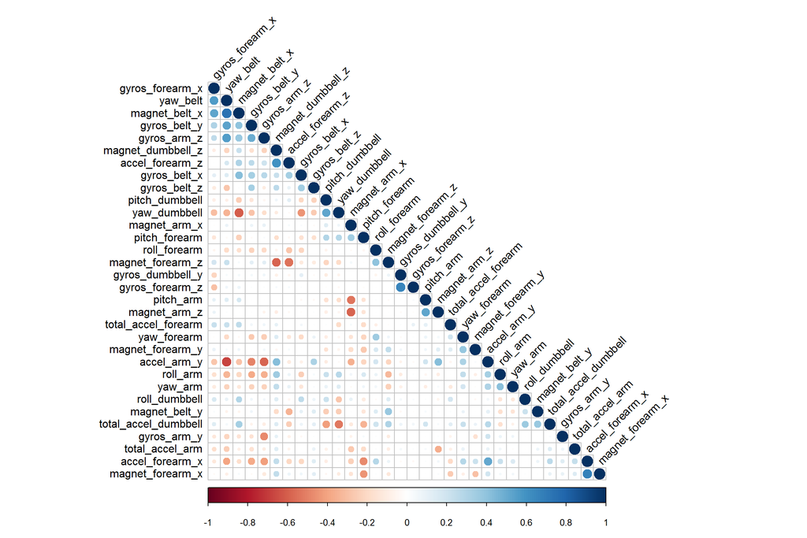

```r
#corrplot(cor(training[,-1]), order = "FPC", method = "color", type = "lower", tl.cex = 0.8, tl.col = rgb(0, 0, 0))
corrplot(cor(training[,-1]), type = "lower", order = "hclust", tl.col = "black", tl.srt = 45)
```

## Model Selection

We are going to use Random Forest (rf), Boosting with Trees (gbm) and Linear Discriminant Analysis (lda) methods to model the training data. And then use cross validation dataset to estimate their accuracy.

### 1. Random Forest

```r
set.seed(355)
# apply random forest
controlRF <- trainControl(method="cv", number=3, verboseIter=FALSE)
train.rf <- train(classe ~ ., data=training, method="rf", trControl=controlRF)
train.rf$finalModel
```

```
##
## Call:
##  randomForest(x = x, y = y, mtry = param$mtry)
##                Type of random forest: classification
##                      Number of trees: 500
## No. of variables tried at each split: 2
##
##         OOB estimate of  error rate: 0.8%
## Confusion matrix:
##      A    B    C    D    E  class.error
## A 3904    2    0    0    0 0.0005120328
## B   15 2636    7    0    0 0.0082768999
## C    0   26 2359   11    0 0.0154424040
## D    0    0   39 2211    2 0.0182060391
## E    0    1    3    4 2517 0.0031683168
```

```r
# apply fitted model to test data
test.rf <- predict(train.rf, testing)
# compare results
cm_rf <-confusionMatrix(testing$classe,test.rf)
print(cm_rf)
```

```
## Confusion Matrix and Statistics
##
##           Reference
## Prediction    A    B    C    D    E
##          A 1673    1    0    0    0
##          B    4 1132    2    0    1
##          C    0   11 1011    4    0
##          D    0    0   24  939    1
##          E    0    0    0    6 1076
##
## Overall Statistics
##
##                Accuracy : 0.9908
##                  95% CI : (0.988, 0.9931)
##     No Information Rate : 0.285
##     P-Value [Acc > NIR] : < 2.2e-16
##
##                   Kappa : 0.9884
##  Mcnemar's Test P-Value : NA
##
## Statistics by Class:
##
##                      Class: A Class: B Class: C Class: D Class: E
## Sensitivity            0.9976   0.9895   0.9749   0.9895   0.9981
## Specificity            0.9998   0.9985   0.9969   0.9949   0.9988
## Pos Pred Value         0.9994   0.9939   0.9854   0.9741   0.9945
## Neg Pred Value         0.9991   0.9975   0.9946   0.9980   0.9996
## Prevalence             0.2850   0.1944   0.1762   0.1613   0.1832
## Detection Rate         0.2843   0.1924   0.1718   0.1596   0.1828
## Detection Prevalence   0.2845   0.1935   0.1743   0.1638   0.1839
## Balanced Accuracy      0.9987   0.9940   0.9859   0.9922   0.9984
```

#### 2. Boosting with Trees

```r
# apply gbm
train.gbm <- train(classe ~ ., data=training, method="gbm",verbose=F)
# apply fitted model to test data
test.gbm <- predict(train.gbm, testing)
# compare results
cm_gbm <-confusionMatrix(testing$classe,test.gbm)
print(cm_gbm)
```

```
## Confusion Matrix and Statistics
##
##           Reference
## Prediction    A    B    C    D    E
##          A 1645   21    5    3    0
##          B   36 1060   34    5    4
##          C    3   60  943   18    2
##          D    4    4   48  899    9
##          E    3   16   14   26 1023
##
## Overall Statistics
##
##                Accuracy : 0.9465
##                  95% CI : (0.9404, 0.9521)
##     No Information Rate : 0.2873
##     P-Value [Acc > NIR] : < 2.2e-16
##
##                   Kappa : 0.9323
##  Mcnemar's Test P-Value : 7.49e-08
##
## Statistics by Class:
##
##                      Class: A Class: B Class: C Class: D Class: E
## Sensitivity            0.9728   0.9130   0.9033   0.9453   0.9855
## Specificity            0.9931   0.9833   0.9829   0.9868   0.9878
## Pos Pred Value         0.9827   0.9306   0.9191   0.9326   0.9455
## Neg Pred Value         0.9891   0.9787   0.9792   0.9894   0.9969
## Prevalence             0.2873   0.1973   0.1774   0.1616   0.1764
## Detection Rate         0.2795   0.1801   0.1602   0.1528   0.1738
## Detection Prevalence   0.2845   0.1935   0.1743   0.1638   0.1839
## Balanced Accuracy      0.9829   0.9481   0.9431   0.9661   0.9867
```

#### 3. Linear Discriminant Analysis

```r
# apply lda
train.lda <- train(classe ~ ., data=training, method="lda",verbose=FALSE)
# apply fitted model to test data
test.lda <- predict(train.lda, testing)
# compare results
cm_lda <-confusionMatrix(testing$classe,test.lda)
print(cm_lda)
```

```
## Confusion Matrix and Statistics
##
##           Reference
## Prediction    A    B    C    D    E
##          A 1121  231  168  121   33
##          B  247  573  149   99   71
##          C  164  101  628  113   20
##          D   50   92  140  575  107
##          E   84  183  145  153  517
##
## Overall Statistics
##
##                Accuracy : 0.5801
##                  95% CI : (0.5674, 0.5928)
##     No Information Rate : 0.2831
##     P-Value [Acc > NIR] : < 2.2e-16
##
##                   Kappa : 0.4694
##  Mcnemar's Test P-Value : < 2.2e-16
##
## Statistics by Class:
##
##                      Class: A Class: B Class: C Class: D Class: E
## Sensitivity            0.6729  0.48559   0.5106  0.54194  0.69118
## Specificity            0.8689  0.87970   0.9145  0.91936  0.89001
## Pos Pred Value         0.6697  0.50307   0.6121  0.59647  0.47782
## Neg Pred Value         0.8706  0.87210   0.8761  0.90124  0.95191
## Prevalence             0.2831  0.20051   0.2090  0.18029  0.12710
## Detection Rate         0.1905  0.09737   0.1067  0.09771  0.08785
## Detection Prevalence   0.2845  0.19354   0.1743  0.16381  0.18386
## Balanced Accuracy      0.7709  0.68265   0.7125  0.73065  0.79060
```

## Result

The accuracy comparison of each model below indicates that the random forest has the highest accuracy. Therefore it will be used for the test set prediction.

```r
rbind(Accuracy = c(rf = cm_rf$overall[1], gbm = cm_gbm$overall[1],lda = cm_lda$overall[1]))
```

```
##          rf.Accuracy gbm.Accuracy lda.Accuracy
## Accuracy   0.9908241    0.9464741    0.5801189
```

## Apply selected machine learning algorithm to the 20 test cases

```r
testCases <- predict(train.rf, newdata=testSet)
print(testCases)
```

```
##  [1] B A B A A E D B A A B C B A E E A B B B
## Levels: A B C D E
```